[OHI British Columbia](http://www.ohibc.org/) | [OHI Science](http://ohi-science.org) | [Citation policy](https://github.com/OHI-Science/ohiprep/releases)

# CMSY for BC stocks

This script reruns catch-MSY on all SAUP data for stocks in FAO area 67 (British Columbia).

# SAUP data for British Columbia

Read in the stock catch by region calculated for global OHI 2017 from SAUP data. Filter just for species records (taxon key > 599999). We also need to add resilience measures for the cmsy model. We can use the resilience lookup table from global

```r
res <- read_csv("~/github/ohiprep/globalprep/fis/v2017/data/taxon_resilience_lookup.csv")

catch <- read_csv(file.path(dir_M,'git-annex/globalprep/fis/v2017/int/stock_catch_by_rgn.csv')) %>%
  rename(common = taxon_common_name, fao_id = fao_rgn, species=taxon_scientific_name) %>%
  filter(fao_id == 67,
         taxon_key > 599999) %>%
  group_by(year, species, common, stock_id) %>%
  mutate(annual_catch = sum(tons)) %>%
  select(year, sciname = species, common, annual_catch) %>%
  distinct() %>%
  left_join(res, by = c("sciname", "common")) %>%
  select(-X1, -SpecCode)

#how many stocks?

length(unique(catch$sciname)) #92
```

```
## [1] 92
```

```r
# how many of these stocks are found in Canadian waters in 67?

ca_stocks <- read_csv(file.path(dir_M,'git-annex/globalprep/fis/v2017/int/stock_catch_by_rgn.csv')) %>%
  filter(fao_rgn == 67,
         rgn_id==218,
         taxon_key > 599999) %>%
  select(taxon_scientific_name, taxon_common_name, stock_id) %>%
  distinct()

#nrow(ca_stocks)  #81

DT::datatable(ca_stocks)
```

|  | taxon_scientific_name | taxon_common_name | stock_id |
| --- | --- | --- | --- |
| 1 | Alosa sapidissima | American shad | Alosa_sapidissima-67 |
| 2 | Anoplopoma fimbria | Sablefish | Anoplopoma_fimbria-67 |
| 3 | Atheresthes stomias | Arrowtooth flounder | Atheresthes_stomias-67 |
| 4 | Atractoscion nobilis | White weakfish | Atractoscion_nobilis-67 |
| 5 | Cancer productus | Pacific rock crab | Cancer_productus-67 |
| 6 | Citharichthys sordidus | Pacific sanddab | Citharichthys_sordidus-67 |
| 7 | Clinocardium nuttallii | Nuttall cockle | Clinocardium_nuttallii-67 |
| 8 | Clupea pallasii pallasii | Pacific herring | Clupea_pallasii_pallasii-67 |
| 9 | Coregonus laurettae | Bering cisco | Coregonus_laurettae-67 |
| 10 | Coregonus pidschian | Humpback whitefish | Coregonus_pidschian-67 |

[output cut: 71 more lines]

There are **81 stocks** in Canadian BC waters.

# Assess what stocks meet reqs of CMSY

Let’s filter out the catch to just incude those found in Canadian waters. We also need to filter out stocks that dont have at least a 20 yr time series and an annual avg catch of 1000 tons.

```r
stocks_for_cmsy <- catch %>%
  filter(sciname %in% ca_stocks$taxon_scientific_name,
         str_detect(common, "almon")==FALSE) %>% #remove salmon
  group_by(stock_id)%>%
  mutate(nyrs = n(),                       #get the total number of years the stock has records for
         avg_ann_catch = mean(annual_catch)) %>%    #calculate the mean catch over all catch years
  mutate(run_cmsy = ifelse(nyrs > 19 & avg_ann_catch >= 1000, "yes", "no")) %>%
  select(sciname, common, nyrs, avg_ann_catch, run_cmsy) %>%
  distinct()

DT::datatable(stocks_for_cmsy)
```

|  | stock_id | sciname | common | nyrs | avg_ann_catch | run_cmsy |
| --- | --- | --- | --- | --- | --- | --- |
| 1 | Clupea_pallasii_pallasii-67 | Clupea pallasii pallasii | Pacific herring | 65 | 151081.331976884 | yes |
| 2 | Coregonus_laurettae-67 | Coregonus laurettae | Bering cisco | 65 | 2.77420531699706 | no |
| 3 | Coregonus_pidschian-67 | Coregonus pidschian | Humpback whitefish | 65 | 16.048472606894 | no |
| 4 | Coregonus_sardinella-67 | Coregonus sardinella | Sardine cisco | 65 | 1.80814935155637 | no |
| 5 | Erimacrus_isenbeckii-67 | Erimacrus isenbeckii | Hair Crab | 65 | 0.17692258803991 | no |
| 6 | Hippoglossus_stenolepis-67 | Hippoglossus stenolepis | Pacific halibut | 65 | 39961.157115579 | yes |
| 7 | Mallotus_villosus-67 | Mallotus villosus | Capelin | 65 | 106.346296626203 | no |
| 8 | Microgadus_proximus-67 | Microgadus proximus | Pacific tomcod | 65 | 20.8823002981573 | no |
| 9 | Oncorhynchus_mykiss-67 | Oncorhynchus mykiss | Rainbow trout | 65 | 93.0513386300466 | no |
| 10 | Paralithodes_camtschaticus-67 | Paralithodes camtschaticus | Red king crab | 65 | 17780.50406854 | yes |

[output cut: 66 more lines]

There are only **27 stocks** to run through CMSY. In the table you can see the main reason we can’t run CMSY on a majority of the stocks is due to low annual average catch.

# Prep data for CMSY

```r
#prepping the catch data for CMSY model
catch_for_cmsy <- catch %>%
  filter(sciname %in% ca_stocks$taxon_scientific_name,
         str_detect(common, "almon")==FALSE) %>% #remove salmon
  group_by(stock_id) %>%
  mutate(nyrs = n(),                       #get the total number of years the stock has records for
         avg_ann_catch = mean(annual_catch)) %>%    #calculate the mean catch over all catch years
  filter(nyrs > 19,
         avg_ann_catch >= 1000)

#length(unique(catch_for_cmsy$stock_id))
```

# Run CMSY

Run the model on the 27 stocks.

```r
if (!file.exists(file.path(dir_M,"git-annex/bcprep/fis/v2017/cmsy_fits/cmsy-fits.rds"))) {

cmsy_fits <- plyr::dlply(catch_for_cmsy, c("stock_id", "common"), function(x) {

    #make sure the data is ordered from 1950 to 2010
    x <- arrange(x,year)
    out <- cmsy(ct = x$annual_catch, yr = x$year,  start_r = resilience(x$Resilience[1]),
      reps = 2e6)
    out$year <- x$year
    out
  }, .parallel = TRUE)
saveRDS(cmsy_fits, file = file.path(dir_M,"git-annex/bcprep/fis/v2017/cmsy_fits/cmsy-fits.rds"))
} else {
  cmsy_fits <- readRDS(file.path(dir_M,"git-annex/bcprep/fis/v2017/cmsy_fits/cmsy-fits.rds"))
}

fake_data <- data.frame(bbmsy_q2.5 = NA, bbmsy_q25 = NA, bbmsy_q50 = NA,
  bbmsy_q75 = NA, bbmsy_q97.5 = NA)

cmsy_bbmsy <- plyr::ldply(cmsy_fits, function(x) {
  bbmsy_cmsy <- x$biomass[, -1] / x$bmsy
  bbmsy_out <- tryCatch({
    bbmsy_out <- summarize_bbmsy(bbmsy_cmsy)
    bbmsy_out$year <- x$year
    bbmsy_out}, error = function(e) fake_data)
})
cmsy_bbmsy$model <- "CMSY"

write.csv(cmsy_bbmsy,file='v2017/int/cmsy_bbmsy.csv')
```

# Plot bbmsy for all stocks

Remove the stocks for which we have assessments from RAM. This includes: Pacific Halibut, Lingcod, Pacific ocean perch, rock sole and sablefish

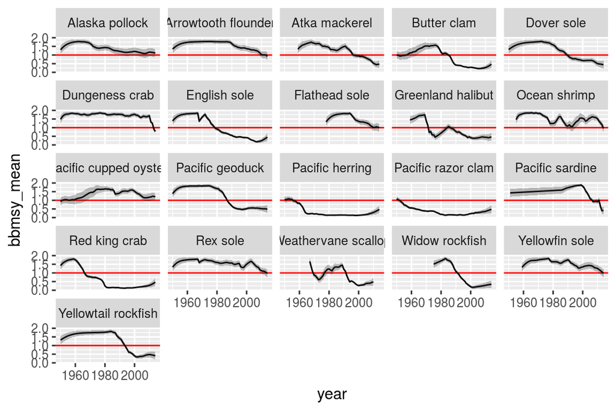

```r
cmsy_bbmsy <- read_csv("v2017/int/cmsy_bbmsy.csv") %>%
  filter(!common %in% c("Pacific halibut", "Pacific cod", "Lingcod", "Pacific ocean perch", "Rock sole", "Sablefish"))

ggplot(cmsy_bbmsy, aes(x = year, y = bbmsy_mean)) +
  geom_hline(yintercept = 1, col = "red") +
  geom_line() +
  geom_ribbon(aes(ymin=bbmsy_mean-bbmsy_sd,ymax=bbmsy_mean+bbmsy_sd),alpha=0.3) +
  facet_wrap(~common)
```

Compare the stocks we have in RAM

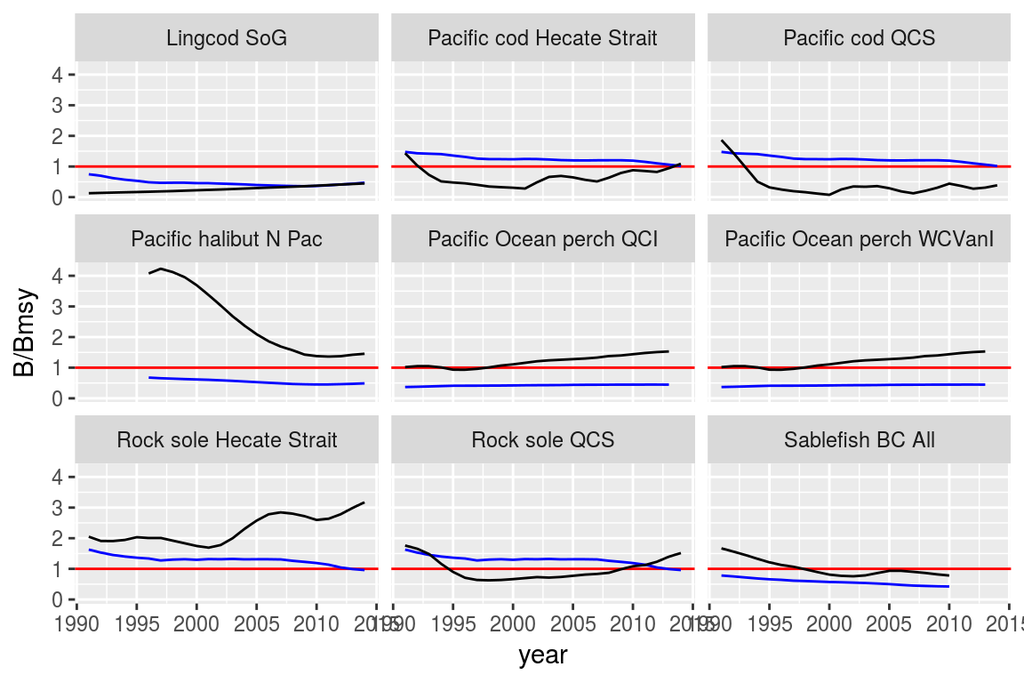

```r
cmsy_bbmsy <- read_csv("v2017/int/cmsy_bbmsy.csv") %>%
  filter(common %in% c("Pacific halibut", "Pacific cod", "Lingcod", "Pacific ocean perch", "Rock sole", "Sablefish"))

#plot RAM species
stocks_ts_df <- bind_rows(read_csv(file.path(dir_goal, 'output/ram_b_bmsy.csv')),
                     read_csv(file.path(dir_goal, 'output/ram_f_fmsy.csv'))) %>%
  left_join(read_csv(file.path(dir_goal, 'raw', '1_ram_ids_to_names.csv'))) %>%
  ungroup() %>%
  mutate(param = str_replace_all(tolower(param), '[^a-z]', '_') %>%
        str_replace_all('u', 'f')) %>%
  filter(!stock_name_mod %in% c("Albacore tuna N Pac", "Bocaccio BC All")) %>%
  mutate(common = case_when(
    stock_name_mod == "Lingcod SoG" ~ "Lingcod",
    stock_name_mod == "Pacific cod Hecate Strait" ~ "Pacific cod",
    stock_name_mod == "Pacific cod QCS" ~ "Pacific cod",
    stock_name_mod == "Pacific halibut N Pac" ~ "Pacific halibut",
    stock_name_mod == "Pacific Ocean perch QCI" ~ "Pacific ocean perch",
    stock_name_mod == "Pacific Ocean perch WCVanI" ~ "Pacific ocean perch",
    stock_name_mod == "Rock sole Hecate Strait" ~ "Rock sole",
    stock_name_mod == "Rock sole QCS" ~ "Rock sole",
    stock_name_mod == "Sablefish BC All" ~ "Sablefish"
  )) %>%
  filter(param == "b_bmsy") %>%
  left_join(cmsy_bbmsy, by = c("common", "year")) %>%
  filter(year>1990)


ggplot(stocks_ts_df, aes(x = year)) +
  geom_hline(yintercept = 1, col = "red") +
  geom_line(aes(y = bbmsy_mean), color = "blue") +
  geom_line(aes(y = value), color = "black") +
  facet_wrap(~stock_name_mod) +
  ylab("B/Bmsy")
```